# Iris Example

DSI Workshop

# First Section: Iris Violin Plot

## Subsection: Original Code

- Let’s revisit the violin plot of the Iris data from the `ggplot2` section of the workshop.
- The code can be embedded in the R Markdown document. When the document is compiled, the code will be executed (`eval = TRUE` in the Rmd source) and the resulting plot will be included in the document.
- The code itself is also printed because of the option `echo = TRUE` (also in the Rmd source).
- The original code from Lingge was:

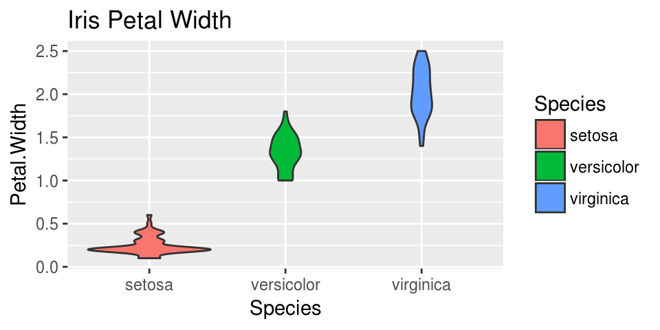

```r
library(ggplot2)
ggplot(data = iris, aes(x = Species, y = Petal.Width)) +
  geom_violin(aes(fill = Species)) +
  labs(title = 'Iris Petal Width')
```

## Using Chunk Options

[Adapted from the R Markdown Cheat Sheet](https://www.rstudio.com/wp-content/uploads/2015/02/rmarkdown-cheatsheet.pdf)

### Subsubsection: Violin Plot

Change the code chunk options so that the code is not displayed and the plot is larger.

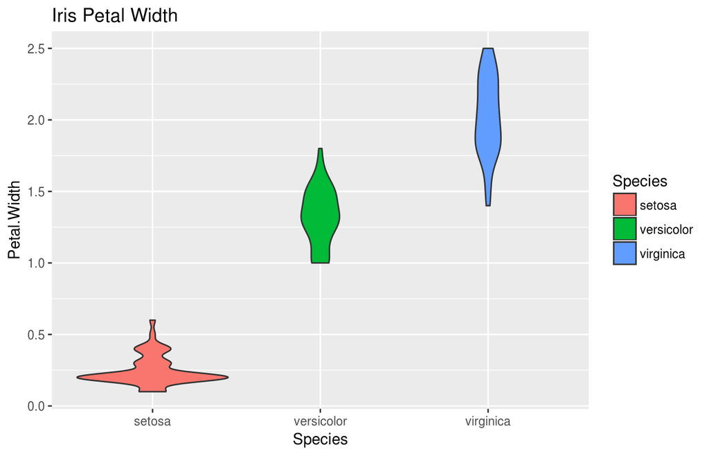

# Images

#### Format to embed images: `![](path/to/smallorb.png)`

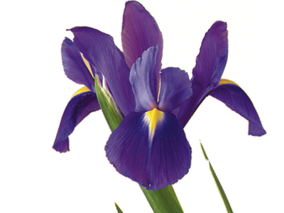

#### To have more control over display options, we can use a code chunk:

```r
knitr::include_graphics('Figures/iris.png')
```

#### Alternatively, we could use HTML to embed the image.

`<img src="Figures/iris.png" alt="Iris" style="align:right;width:604px;height:128px;">`

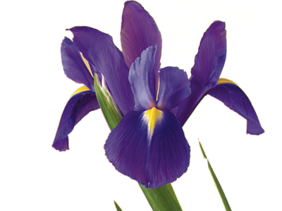

# Some Other R Markdown Features

## Displaying Math

We can easily display mathematical symbols and equations using $\LaTeX$ style formating:

- Here’s an example of an inline equation: $x^2 + y^2 = z^2$.
- We can use many nice $\LaTeX$ options such as Greek letters ($\phi, \alpha, \Sigma$) and math notation ($\int, \infty, \|\cdot\|, \nabla$)
- We can also use display math formats:

$$\sum_{i = 0}^{\infty} \frac{\lambda^x e^{-\lambda}}{x!} = 1$$

## Inline Code

Similar to math, code can be included inline as well: Two plus two equals 4.

- The language must be specified for the code to be executed,
- Displayed only: `levels(iris$Species)`
- Evaluated: setosa, versicolor, virginica

## Displaying Data

#### Display data as it would be printed from the `R` console:

```r
head(iris)
```

```
##   Sepal.Length Sepal.Width Petal.Length Petal.Width Species
## 1          5.1         3.5          1.4         0.2  setosa
## 2          4.9         3.0          1.4         0.2  setosa
## 3          4.7         3.2          1.3         0.2  setosa
## 4          4.6         3.1          1.5         0.2  setosa
## 5          5.0         3.6          1.4         0.2  setosa
## 6          5.4         3.9          1.7         0.4  setosa
```

#### Display data in Table format

##### Using `knitr` and `kable`

```r
knitr::kable(
  head(iris),
  caption = "A knitr kable."
)
```

A knitr kable.

| Sepal.Length | Sepal.Width | Petal.Length | Petal.Width | Species |
| --- | --- | --- | --- | --- |
| 5.1 | 3.5 | 1.4 | 0.2 | setosa |
| 4.9 | 3.0 | 1.4 | 0.2 | setosa |
| 4.7 | 3.2 | 1.3 | 0.2 | setosa |
| 4.6 | 3.1 | 1.5 | 0.2 | setosa |
| 5.0 | 3.6 | 1.4 | 0.2 | setosa |
| 5.4 | 3.9 | 1.7 | 0.4 | setosa |

##### Using `xtable` package

```r
print(xtable::xtable(head(iris), caption = "Table with xtable"), type = "html", html.table.attributes = "border=1")
```

Table with xtable

|  | Sepal.Length | Sepal.Width | Petal.Length | Petal.Width | Species |
| --- | --- | --- | --- | --- | --- |
| 1 | 5.10 | 3.50 | 1.40 | 0.20 | setosa |
| 2 | 4.90 | 3.00 | 1.40 | 0.20 | setosa |
| 3 | 4.70 | 3.20 | 1.30 | 0.20 | setosa |
| 4 | 4.60 | 3.10 | 1.50 | 0.20 | setosa |
| 5 | 5.00 | 3.60 | 1.40 | 0.20 | setosa |
| 6 | 5.40 | 3.90 | 1.70 | 0.40 | setosa |

##### Using `stargazer` package

```r
stargazer::stargazer(head(iris), type = "html", title = "Stargazer Table")
```

**Stargazer Table**

| Statistic | N | Mean | St. Dev. | Min | Max |
| --- | --- | --- | --- | --- | --- |
| Sepal.Length | 6 | 4.950 | 0.288 | 4.600 | 5.400 |
| Sepal.Width | 6 | 3.383 | 0.343 | 3.000 | 3.900 |
| Petal.Length | 6 | 1.450 | 0.138 | 1.300 | 1.700 |
| Petal.Width | 6 | 0.233 | 0.082 | 0.200 | 0.400 |

## Other Tips and Tools

- Can choose a theme for the page style or can provide your own css file
- Can use inline **HTML** to *format text* and include things like links: [More on Building Websites with R Markdown](https://http://rmarkdown.rstudio.com/rmarkdown_websites.html#overview)
- The `bookdown` package can be used to typeset a book using R Markdown.
- Presentations can be created in R Markdown as well using the output document types: `ioslides_presentation`, `slidy_presentation`, `beamer_presentation`, or `xaringan`